# EP03-respuesta-equipo-3

2024-04-02

## PREGUNTA 1

### Si la ingeniera está seguro de que el verdadero volumen medio no puede ser superior a 10 litros y piensa rechazar la hipótesis nula cuando la muestra presente una media menor a 9,8 litros, ¿cuál es la probabilidad de que cometa un error de tipo I? Para responder, generen un gráfico de la distribución muestral de las medias hipotetizada en donde se marque la zona correspondiente a la probabilidad solicitada, para luego, basándose en este gráfico, calcular el área correspondiente. Tome como ejemplo los scripts presentados en la lectura sobre poder estadístico.

#### para responder esta pregunta, tal como se indica se realizara un grafico y se indicara (con color rojo), la zona que representa la probabilidad de cometer un error de tipo 1.

```r
library(ggplot2)
library(ggpubr)
library(ggpattern)
# Definir parámetros
sigma <- 1     # Desviación estándar de los volúmenes de los bidones
n <- 100       # Tamaño de la muestra total (50 de cada máquina)
mu <- 10       # Media poblacional bajo la hipótesis nula (H0)
x_critico <- 9.8   # Criterio para rechazar H0 (media muestral crítica)

# Calcular el Error Estándar de la Media (SEM)
SEM <- sigma / sqrt(n)  # Esto refleja la dispersión de las medias muestrales

# Calcular el Z-score para el valor crítico de 9.8 litros
Z <- (x_critico - mu) / SEM
# Calcular la probabilidad de error de tipo I (área a la izquierda del Z)
alpha <- pnorm(Z)  # Esto da la probabilidad de observar una media ≤ 9.8 si H0 es cierta
print(paste("la probabilidad de cometer un error tipo 1 es de: ", round(alpha*100, 2), "%"))
```

```
## [1] "la probabilidad de cometer un error tipo 1 es de:  2.28 %"
```

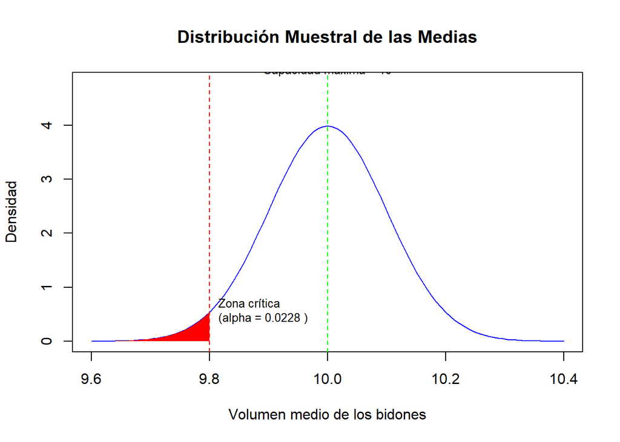

```r
# Generar el gráfico
curve(dnorm(x, mean = mu, sd = SEM), from = mu - 4*SEM, to = mu + 4*SEM, col = "blue", ylab = "Densidad", xlab = "Volumen medio de los bidones", main = "Distribución Muestral de las Medias", ylim = c(0, dnorm(mu, mean = mu, sd = SEM) * 1.2))
abline(v = x_critico, col = "red", lty = 2)  # Línea para la media crítica de rechazo
text(x_critico, dnorm(x_critico, mean = mu, sd = SEM), labels = paste("Zona crítica\n(alpha =", round(alpha, 4), ")"), pos = 4, cex = 0.8, offset = 0.5)

# Sombreado del área bajo la curva desde la línea roja hacia la izquierda
x_vals <- seq(mu - 4*SEM, x_critico, length.out = 100)
y_vals <- dnorm(x_vals, mean = mu, sd = SEM)
polygon(c(mu - 4*SEM, x_vals, x_critico), c(0, y_vals, 0), col = "red", border = NA)

# Línea para la capacidad máxima del bidón
abline(v = mu, col = "green", lty = 2)  # Marca la media poblacional bajo H0
text(mu, dnorm(mu, mean = mu, sd = SEM) * 1.2, labels = "Capacidad máxima = 10", pos = 3, cex = 0.8, offset = 0.5)
```

#### como se puede apreciar el valor referente a la posibilidad de cometer un error de tipo 1 es 0.0228, lo cual si obtenemos el porcentaje es de 2.28%

## Pregunta 2

### Si el verdadero volumen medio de los bidones fuera de 9,85 litros, ¿cuál sería la probabilidad de que la ingeniera, que obviamente no conoce este dato, cometa un error de tipo II? Para responder, agregue al gráfico anterior la verdadera distribución muestral de las medias y marquen (con otro color) la zona correspondiente a la probabilidad solicitada, para luego, basándose en este gráfico, calcular el área correspondiente. También hay ejemplos de este procedimiento en la lectura sobre poder estadístico.

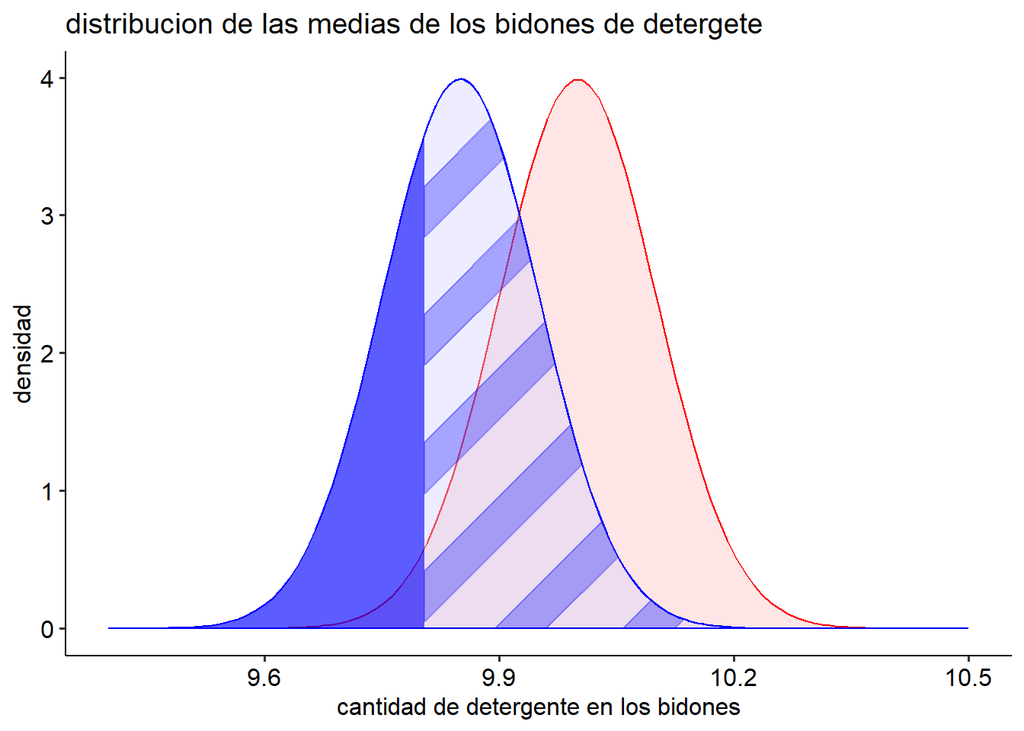

```r
library(ggplot2)
library(ggpubr)
library(ggpattern)

# Se establecen variables
alfa <- 0.05
n <- 100

media_nula <- 10
sigma <- 1

# Se calcula el error estándar
error <- sigma/sqrt(n)

g_xlimites <- media_nula + c(-6,5) * error

g <- ggplot() + xlim(g_xlimites)
g<- g+ labs(x = "cantidad de detergente en los bidones", y = "densidad")
g <- g + labs(title = "distribucion de las medias de los bidones de detergete")
g <- g + theme_pubr()

dist_0 <- stat_function(fun = dnorm,
                        args =list(mean = media_nula, sd = error),
                        geom = "area",
                        colour = "red", fill = "red", alpha = 0.1)

g1 <- g + dist_0
g1 <- g1 + geom_vline(xintercept = media_nula, colour = "red")

z_inferior <- qnorm(alfa/2, mean = media_nula, sd = error, lower.tail = TRUE)
z_superior <- qnorm(alfa/2, mean = media_nula, sd = error, lower.tail = FALSE)

g2 <- g1 + stat_function(fun = dnorm,
                         args = list(mean = media_nula,
                                     sd = error),
                         geom = "area",
                         xlim = c(g_xlimites[1], z_inferior),
                         fill = "red", alpha = 0.6)
g2 <- g2 + stat_function(fun = dnorm,
                         args = list(mean = media_nula, sd = error),
                         geom = "area",
                         xlim = c(z_superior, g_xlimites[2]),
                         fill = "red", alpha = 0.6)

#Valores reales
media_verdadera <- 9.85
delta <- media_nula - media_verdadera

dist_v <- stat_function(fun = dnorm,
                         args = list(mean = media_verdadera,
                                     sd = error),
                         geom = "area",
                         colour = "blue", fill = "blue", alpha = 0.1)

g3 <- g2 + dist_v + geom_vline(xintercept = media_verdadera, colour = "blue")

x_ann <- c(media_verdadera, media_nula)
y_ann <- c(dnorm(media_verdadera, mean = media_verdadera, sd = error),
           dnorm(media_nula, mean = media_nula, sd = error))
y_ann <- y_ann + 0.01

g3 <- g3 + annotate("segment", x = x_ann[1], y = y_ann[1],
                    xend = x_ann[2], yend = y_ann[2],
                    arrow = arrow(angle = 10, length = unit(0.03, "npc"),
                                  ends = "both", type = "open"))

g3 <- g3 + annotate("text", x = sum(x_ann)/2, y = y_ann[1] - 0.001,
                    label = "delta", vjust = "top", parse = TRUE)


g4 <- g+ dist_0 + dist_v
g4<- g4 + stat_function(fun = dnorm,
                        args = list(mean = media_verdadera, sd = error),
                        geom = "area",
                        xlim = c(g_xlimites[1], z_inferior),
                        fill = "blue", alpha = 0.6)

g4<- g4 + stat_function(fun = dnorm,
                        args = list(mean = media_verdadera, sd = error),
                        geom = "area",
                        xlim = c(z_superior, g_xlimites[2]),
                        fill = "blue", alpha = 0.6)

g4<- g4 + stat_function(fun = dnorm,
                        args = list(mean = media_verdadera, sd = error),
                        geom = "area_pattern",
                        xlim = c(z_inferior, z_superior),
                        fill = "white", colour = "blue", alpha = 0.3,
                        pattern_spacing = 0.15, pattern_density = 0.4,
                        pattern_fill = "blue", pattern_colour = "blue",
                        pattern_angle = 45, pattern_alpha = 0.3)

print(g4)
```

```r
#calcular probabildad de cometer un error tipo 2

poder_inf <- pnorm(z_inferior, mean = media_verdadera, sd = error, lower.tail = TRUE)
poder_sup <- pnorm(z_superior, mean = media_verdadera, sd = error, lower.tail = FALSE)

poder <- poder_inf + poder_sup

beta <- 1- poder
cat("error tipo 2", beta)
```

```
## error tipo 2 0.6769588
```

#### se aprecia en el grafico la diferencia media de los bidones de detergente, ademas luego de calcular la probabilidad de cometer un error de tipo 2 es del 67.69588%.

## Pregunta 3

### Como no se conoce el verdadero volumen medio, genere un gráfico del poder estadístico con las condiciones anteriores, pero suponiendo que el verdadero volumen medio podría variar de 9,5 a 10 litros. Hay un ejemplo de este tipo de gráfico en la lectura sobre poder estadístico.

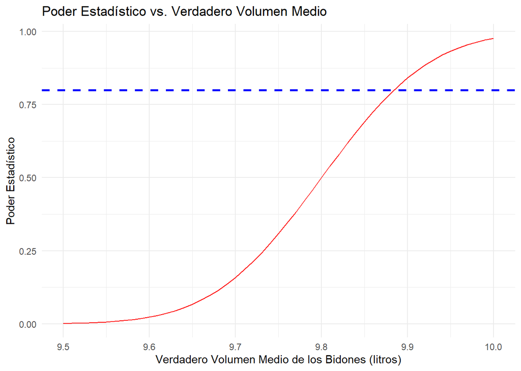

```r
# Cargar librería necesaria
library(ggplot2)

# Definir parámetros
sigma <- 1     # Desviación estándar
n <- 100       # Tamaño de la muestra
mu_h0 <- 10    # Media bajo H0
x_critico <- 9.8  # Media muestral crítica para rechazar H0
SEM <- sigma / sqrt(n)  # Error Estándar de la Media

# Generar secuencia de verdaderos volúmenes medios de 9.5 a 10
mu_real <- seq(9.5, 10, by = 0.01)

# Función para calcular el poder estadístico
calcular_poder <- function(mu) {
  Z <- (x_critico - mu) / SEM
  beta <- pnorm(Z)
  poder <- 1 - beta
  return(poder)
}

# Aplicar la función a cada valor de mu_real
poder_estadistico <- sapply(mu_real, calcular_poder)

# Crear un data frame para el gráfico
datos <- data.frame(mu_real, poder_estadistico)

# Generar gráfico
ggplot(datos, aes(x = mu_real, y = poder_estadistico)) +
  geom_line(color = "red") +
  labs(title = "Poder Estadístico vs. Verdadero Volumen Medio",
       x = "Verdadero Volumen Medio de los Bidones (litros)",
       y = "Poder Estadístico") +
  geom_hline(yintercept = 0.8, linetype = "dashed", color = "blue", size = 1) +
  theme_minimal()
```

## Pregunta 4

### Considerando un volumen medio de 10 litros, ¿cuántos bidones deberían revisarse para conseguir un poder estadístico de 0,75 y un nivel de significación de 0,05?

```r
library(pwr)

# Parámetros para el cálculo
sigma <- 1    # Desviación estándar
delta <- 0.5  # Diferencia mínima significativa que queremos detectar
alpha <- 0.05 # Nivel de significancia
power <- 0.75 # Poder estadístico deseado

# Cálculo del tamaño de muestra necesario utilizando el paquete 'pwr'
result <- pwr.t.test(d = delta / sigma, sig.level = alpha, power = power, type = "two.sample", alternative = "two.sided")

# Mostrar el resultado
print(result)
```

```
##
##      Two-sample t test power calculation
##
##               n = 56.49861
##               d = 0.5
##       sig.level = 0.05
##           power = 0.75
##     alternative = two.sided
##
## NOTE: n is number in *each* group
```

## Pregunta 5

### ¿Alcanzaría esta muestra para detectar la diferencia que la ingeniera sospecha que existe entre las dos máquinas de la planta con las mismas probabilidades de cometer errores?

```r
# Parámetros
n <- 50  # Tamaño de muestra de cada máquina
sd <- 1  # Desviación estándar de la distribución de volumen


poder <- pwr.2p.test(h=ES.h(0.9,0.96), n = n, sig.level = alpha, alternative = "two.sided")

# Imprimimos el poder estadístico
poder
```

```
##
##      Difference of proportion power calculation for binomial distribution (arcsine transformation)
##
##               h = 0.2407853
##               n = 50
##       sig.level = 0.05
##           power = 0.2255917
##     alternative = two.sided
##
## NOTE: same sample sizes
```